# S Task

Matthew Phelps

Feb 15, 2022

# Overview of workflow

Workflow

- Load data
- Clean/Reshape/manage data
- Format outputs (Table 1 & Figure 1)

Extra

- Code available at: https://github.com/matthew-phelps/novo-ssp.git
- {drake} package for workflow management

# Overview of workflow

```r
plan <- drake_plan(
  adsl = read_excel(file_in("input/data.xlsx"), sheet = "ADSL") %>% setDT(),
  adlb = read_excel(file_in("input/data.xlsx"), sheet = "ADLB") %>% setDT(),
  data_review = review_data(adsl, adlb),
  table_1 = make_table_1(data_review),
  fig_1 = make_fig_1(adlb = data_review$adlb),
  report = rmarkdown::render(
    knitr_in("reports/slides.rmd"),
    output_file = file_out("reports/slides.html"),
    output_dir = "reports"
  )
)
```

# Overview of workflow

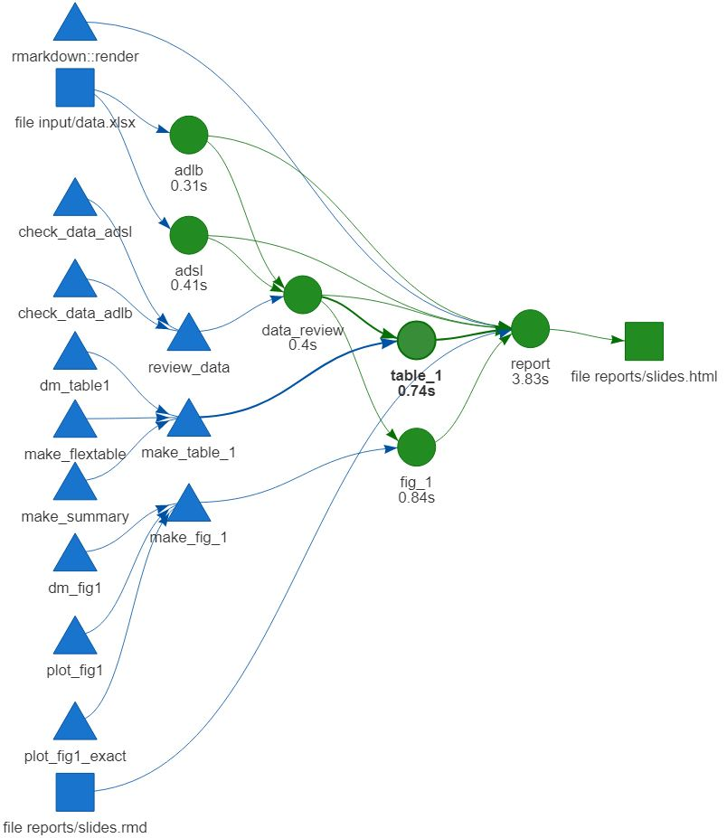

drake plan

# Load data

```r
adsl = read_excel(file_in("input/data.xlsx"), sheet = "ADSL") %>% setDT(),
adlb = read_excel(file_in("input/data.xlsx"), sheet = "ADLB") %>% setDT(),
```

`file_in()` listens for changes in input data file

# Check data

Check both datasets for missing values and unit convertions

ADSL:

```r
adsl <- add_any_miss(adsl, missing = T, complete = F) %>% setDT()
missing <- adsl[any_miss_all == T]
adsl[, map(.SD, hist), .SDcols = range_vars]
out_range <-
  adsl[any_miss_all == F, map(.SD, range), .SDcols = range_vars]
out_unique <-
  adsl[any_miss_all == F, map(.SD, unique), .SDcols = unique_vars]
```

ADLB:

```r
adlb$ANL01REA <- NULL
  adlb <- add_any_miss(adlb, missing = T, complete = F) %>% setDT()
  missing <- adlb[any_miss_all == T]
  plots <- map(unique(adlb$PARAM), function(i){
    gghistogram(adlb[PARAM==i, AVAL],title = i)
  })
  out_range<- adlb[, range(AVAL), by = PARAM]
```

# Check data

### ADSL results

Observations with missing values:

| SUBJID | AGE | AGEU | FASFL | SAFFL | TRT01P | HGTBL | HGTBLU | WGTBL | WGTBLU | DIABDUR | DIABDURU |
| --- | --- | --- | --- | --- | --- | --- | --- | --- | --- | --- | --- |
| S001047 | 73 | YEARS | Y | Y | Treatment A | 1.650 | m | 79.2 | kg | NA | NA |
| S002043 | 61 | YEARS | Y | Y | Treatment A | 1.640 | m | 148.0 | lb | NA | NA |
| S031014 | 68 | YEARS | Y | Y | Treatment B | 1.524 | m | 147.0 | lb | NA | NA |

Range of values:

| AGE | HGTBL | WGTBL | DIABDUR |
| --- | --- | --- | --- |
| 29 | 1.46 | 56.1 | 2 |
| 83 | 181.00 | 325.0 | 36 |

Check units:

| AGEU | HGTBLU | WGTBLU | DIABDURU | TRT01P |
| --- | --- | --- | --- | --- |
| YEARS | m | lb | years | Treatment B |
| YEARS | m | kg | years | Treatment A |

Table 1

# Data management: Table 1

1. Filter lab dataset to desired observations

```r
adlb <- adlb[VISITNUM == 10 & PARAMCD == "C64849B" & FASFL == "Y"]
```

2. Check for duplicated subjects

```r
dub <- adlb[duplicated(SUBJID)]$SUBJID
adlb[SUBJID == dub][,.(SUBJID, TRTP, AVAL, ANL01FL, ANL01REA)]
```

```
##     SUBJID        TRTP AVAL ANL01FL    ANL01REA
## 1: S101066 Treatment B  8.6       Y        <NA>
## 2: S101066 Treatment B  7.9       N Retest rule
```

3. Check for subjects who are in ADSL, but not in ADLB, and subjects who are in ADLB, but not in ADSL

```r
not_in_adlb <- adsl[FASFL == "Y"][!SUBJID %in% adlb$SUBJID] %>% nrow()
not_in_adsl <- adlb[!SUBJID %in% adsl$SUBJID] %>% nrow()
```

# Data management: Table 1

4. Merge lab and subject level datasets and check for missing observations

```r
dat <- merge(adlb, adsl, all = TRUE, by = "SUBJID", suffixes = c("_adlb", "_adsl"))
```

5. Check for discrepancies in the FASFL values and treatment group between datasets

```r
  no_anomaly <- c(dat[FASFL_adlb==FASFL_adsl]$SUBJID, dat[TRTP==TRT01P]$SUBJID)
  dat[!SUBJID %in% c(no_anomaly)]
```

# Data cleaning review: Table 1

- Subjects not in ADSL data: 2
- Subjects not in ADLB data: 4
- No discrepancies in FASFL values or treatment groups.

### Assumptions:

- Treatment group is based on `TRT01P` variable.
- Observations with missing Planned treatment period `TRT01P` (N = 2)  
  are assigned value from TRTP variable.
- Observation with Analysis Record Flag 01 `ANL01FL`== “N” are removed from the analysis (N=1).
- Observation with height of 181m is typo, changed to 1.81m.

# Making table 1

1. Calculate summary statistics by grouping variable (TRT01P)

```r
# var = variable to be summarized
# dig and diag2 = number of significant digits

tab_summary <- dat[!is.na(get(var)), .(
  n = .N,
  med = formatC(median(get(var), na.rm = T),
                digits = dig,
                format = "f"),
  mean = round(mean(get(var), na.rm = T), digits = dig),
  sd = round(sd(get(var), na.rm = T), digits = dig),
  min = formatC(
    round(min(get(var), na.rm = T), digits = dig2),
    digits = dig2,
    format = "f"
  ),
  max = formatC(
    round(max(get(var), na.rm = T), digits = dig2),
    digits = dig2,
    format = "f"
  )
), by = TRT01P] %>%
  .[order(TRT01P)] %>%
  t()
```

2. Reshape and format results so it can latter be fed into {flextable}

```r
  out <- data.table(
    N = c(tab_summary["n", ], tot["n", ]),
    "Mean (SD)" = c(paste0(tab_summary['mean', ]," (", tab_summary["sd", ], ")"),
                    paste0(tot['mean', ], " (", tot["sd", ], ")")),
    Median = c(tab_summary["med", ], tot["med", ]),
    "Min ; Max" = c(paste0(tab_summary['min', ], " ; ", tab_summary["max", ]),
                    paste0(tot['min', ], " ; ", tot["max", ]))
  )
  m <- out %>% t() %>% as.data.frame() %>% setDT()
  m[, value := names(out)]
  setcolorder(m, "value")
```

3. Do this for each variable of interest

```r
    pmap(list(ls$var, ls$dig, ls$dig2, ls$label), function(a, b, c, d) {
      make_summary(
        dat$dat,
        var = a,
        dig = b,
        dig2 = c,
        label = d
      )
    })
```

# Table 1

Table 1 - Baseline and diabetes characteristics - summary - full analysis set

|  |  |  | Treat A |  | Treat B |  | Total |
| --- | --- | --- | --- | --- | --- | --- | --- |
| Number of Subjects |  | 129 |  | 130 |  | 259 |  |
| Age (yrs) |  |  |  |  |  |  |  |
|  | N | 127 |  | 130 |  | 257 |  |
|  | Mean (SD) |  | 60.0 (8.5) |  | 59.3 (9.7) |  | 59.6 (9.1) |
|  | Median |  | 61.0 |  | 60.0 |  | 61.0 |
|  | Min ; Max |  | 36 ; 83 |  | 29 ; 82 |  | 29 ; 83 |
| Height (m) |  |  |  |  |  |  |  |
|  | N | 127 |  | 130 |  | 257 |  |
|  | Mean (SD) |  | 1.68 (0.09) |  | 1.69 (0.11) |  | 1.69 (0.1) |
|  | Median |  | 1.69 |  | 1.69 |  | 1.69 |
|  | Min ; Max |  | 1.49 ; 1.93 |  | 1.46 ; 1.91 |  | 1.46 ; 1.93 |
| Body Weight (kg) |  |  |  |  |  |  |  |
|  | N | 127 |  | 130 |  | 257 |  |
|  | Mean (SD) |  | 89.0 (16.2) |  | 89.5 (17.5) |  | 89.3 (16.8) |
|  | Median |  | 89.8 |  | 86.7 |  | 88.0 |
|  | Min ; Max |  | 54.9 ; 147.4 |  | 53.5 ; 139.3 |  | 53.5 ; 147.4 |
| Duration of Diabetes (yrs) |  |  |  |  |  |  |  |
|  | N | 125 |  | 129 |  | 254 |  |
|  | Mean (SD) |  | 12.0 (6.2) |  | 12.8 (6.6) |  | 12.4 (6.4) |
|  | Median |  | 10.0 |  | 11.0 |  | 11.0 |
|  | Min ; Max |  | 2.0 ; 31.0 |  | 2.0 ; 36.0 |  | 2.0 ; 36.0 |
| HbA1c (%) |  |  |  |  |  |  |  |
|  | N | 127 |  | 128 |  | 255 |  |
|  | Mean (SD) |  | 7.8 (0.6) |  | 8.0 (0.7) |  | 7.9 (0.7) |
|  | Median |  | 7.8 |  | 7.9 |  | 7.8 |
|  | Min ; Max |  | 5.3 ; 9.6 |  | 6.8 ; 10.6 |  | 5.3 ; 10.6 |

N: Number of subjects, SD: Standard Deviation, Min: Minimum, Max: Maximum, yrs: Years, m: Meter, kg: Kilogram

Figure 1

# Data management - Figure 1

1. Filter to selected observations

```r
x <- adlb[PARAMCD == "C64849B" & FASFL == "Y"]
x <- x[ANL01FL == "Y"]
```

2. Extract week number

```r
  x[, week_numb := strsplit(x$AVISIT, "\\(Week |\\)") %>% sapply("[", 2)]
  x[, week_numb := as.integer(week_numb)]
```

3. Mean by treatment group (`TRTP`)

```r
  x[, mean := mean(AVAL), by = .(AVISIT, TRTP)]
  dat_plot <- x[, .SD[1], by = .(TRTP, AVISIT)]
```

# Making Figure 1

1. Create Y-axis ticks that start on a even decimal and cover the data range

```r
  y_min <- floor(plot_range[1]*10)/10
  y_min <- y_min-(y_min)%%.2

  y_max <- ceiling(plot_range[2]*10)/10
  y_max <- y_max+(y_max)%%.2
```

2. Make the ggplot

```r
plot <- ggplot(dat_plot) +
    geom_line(aes(
      x = week_numb,
      y = mean,
      group = TRTP,
      color = TRTP
    ), size=1) +
    geom_point(aes(
      x = week_numb,
      y = mean,
      group = TRTP,
      color = TRTP
    ), size=3)+
    geom_hline(yintercept = 7, color="black")+
    geom_hline(yintercept = 6.5, color="black")+
    geom_vline(xintercept = 0, color="black")
```

# Making Figure 1

3. Formatting plot

```r
plot+theme_bw()+
    labs(caption = "Figure 1 - Mean plot of HbA1c by time - full analysis set")+
    xlab("Week")+
    theme(panel.grid = element_blank(),
          plot.caption = element_text(hjust = 0,
                                      size = 14))+
    scale_color_manual(name="Treatment group", values = c("#E69F00", "#56B4E9"))+
    scale_y_continuous(name="HbA1c (%)",limits = c(y_min, y_max), breaks = seq(y_min, y_max, by=0.2))
```

# Figure 1

[figure not shown]

# Supp - Figure 1

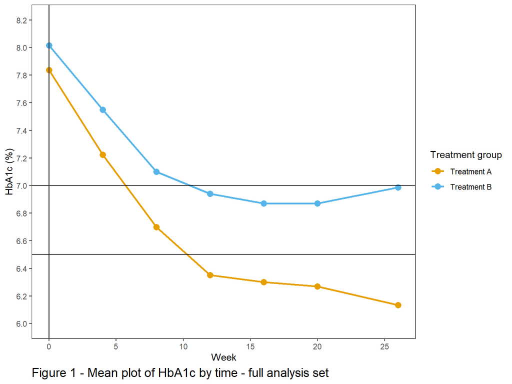

# Supp - flextable

Construct the flextable object

```r
make_flextable <- function(flex) {
  n_col <- ncol(flex)
  n_row <- nrow(flex)

  align_seq <- c(1, seq(3, n_row, by = 5))
  flextable(flex)  %>%
    merge_h_range(i = 1,
                  j1 = 1,
                  j2 = 2) %>%
    merge_h_range(i = seq(2, 22, by = 5),
                  j1 = 1,
                  j2 = n_col) %>%
    merge_h_range(i = align_seq,
                  j1 = 3,
                  j2 = 4) %>%
    merge_h_range(i = align_seq,
                  j1 = 5,
                  j2 = 6) %>%
    merge_h_range(i = align_seq,
                  j1 = 7,
                  j2 = 8) %>%
    width(j = 1, width = 0.2) %>%
    width(j = 2:2, width = 2) %>%
    width(j = 3:n_col, width = 1) %>%
    width(j = seq(3, 7, 2), width = .2) %>%
    set_header_labels(
      label = "",
      value = "",
      a_n = "",
      b_n = "",
      tot_n = "",
      a_z = "Treat A",
      b_z = "Treat B",
      tot_z = "Total"
    ) %>%
    set_caption(
      "Table 1 - Baseline and diabetes characteristics - summary - full analysis set",
      autonum = NULL,
      style = "Table Caption",
      html_escape = TRUE
    ) %>%
    add_footer_lines(
      values = c(
        "N: Number of subjects, SD: Standard Deviation, Min: Minimum,
        Max: Maximum, yrs: Years, m: Meter, kg: Kilogram"
      )
    )
}
```

# Supp - functions

```r
review_data <- function(adsl, adlb) {
  range_vars <- c("AGE", "HGTBL", "WGTBL", "DIABDUR")
  unique_vars <- c("AGEU", "HGTBLU", "WGTBLU", "DIABDURU", "TRT01P")

  # Save this to show on slides
  first_check_adsl <- check_data_adsl(adsl, range_vars, unique_vars)
  adsl[which.max(HGTBL)]
  adsl[which.min(HGTBL)]
  adsl[which.max(HGTBL), HGTBL := HGTBL / 100]
  adsl[WGTBLU == "lb", WGTBL := WGTBL * 0.453592]
  adsl[WGTBLU == "lb", WGTBLU := "kg"]
  check_data_adsl(adsl, range_vars, unique_vars)


  range_vars <- c("VISITNUM", "AVAL")
  unique_vars <- c("AVALU")
  first_check_adlb <- check_data_adlb(adlb, range_vars, unique_vars)
  list(adsl = adsl,
       adlb = adlb,
       first_check_adsl=first_check_adsl,
       first_check_adlb=first_check_adlb)
}
```

```r
make_table_1 <- function(data_review) {
  # The variables to be summarized
  adsl <- data_review$adsl
  adlb <- data_review$adlb
  ls <- list(
    var = c("AGE", "HGTBL", "WGTBL", "DIABDUR", "AVAL"),
    label = c(
      "Age (yrs)",
      "Height (m)",
      "Body Weight (kg)",
      "Duration of Diabetes (yrs)",
      "HbA1c (%)"
    ),
    dig = c(1, 2, rep(1, 3)),
    dig2 = c(0, 2, rep(1, 3))
  )

  dat <- dm_table1(adsl, adlb, ls = ls)

  out <-
    pmap(list(ls$var, ls$dig, ls$dig2, ls$label), function(a, b, c, d) {
      make_summary(
        dat$dat,
        var = a,
        dig = b,
        dig2 = c,
        label = d
      )
    })
  tmp <- dat$dat[, .N, by = TRT01P] %>%
    .[order(TRT01P)] %>%
    .[, .(N)] %>%
    t() %>%
    data.frame() %>%
    setDT()

  names(tmp) <-  c("a_n", "b_n")
  tmp <- cbind(data.table(label = "Number of Subjects"), tmp)
  tmp[, tot_n := dat$dat[, .N]]


  flex <- map(out, rbindlist, fill = T) %>% rbindlist()
  flex <- rbindlist(list(tmp, flex), fill = T)
  flex[,sort(names(flex))]
  setcolorder(flex, sort(names(flex)))
  setcolorder(flex, c("label", "value"))
flex
  table_out <- make_flextable(flex)

  read_docx() %>%
    body_add_flextable(value = table_out) %>%
    print(target = "output/Table 1.docx")
  return(list(table = table_out, missing = dat$missing))
}
```

```r
make_summary  <- function(dat, var, dig, dig2, label) {

  # Stats by grouping variable
  tab_summary <- dat[!is.na(get(var)), .(
    n = .N,
    med = formatC(
      median(get(var), na.rm = T),
      digits = dig,
      format = "f"
    ),
    mean = round(mean(get(var), na.rm = T), digits = dig),
    sd = round(sd(get(var), na.rm = T), digits = dig),
    min = formatC(
      round(min(get(var), na.rm = T), digits = dig2),
      digits = dig2,
      format = "f"
    ),
    max = formatC(
      round(max(get(var), na.rm = T), digits = dig2),
      digits = dig2,
      format = "f"
    )
  ), by = TRT01P] %>%
    .[order(TRT01P )] %>%
    t()

  # Stats by total (i.e. no groping variable)
  tot <- dat[!is.na(get(var)), .(
    n = .N,
    med = formatC(
      median(get(var), na.rm = T),
      digits = dig,
      format = "f"
    ),
    mean = round(mean(get(var), na.rm = T), digits = dig),
    sd = round(sd(get(var), na.rm = T), digits = dig),
    min = formatC(
      round(min(get(var), na.rm = T), digits = dig2),
      digits = dig2,
      format = "f"
    ),
    max = formatC(
      round(max(get(var), na.rm = T), digits = dig2),
      digits = dig2,
      format = "f"
    )
  )]  %>%t()

  # Reshape and format results so it can latter be fed into flextable
  out <- data.table(
    # N = c(tab_summary["n", ], tot["n", ]),
    "Mean (SD)" = c(paste0(tab_summary['mean', ], " (", tab_summary["sd", ], ")"), paste0(tot['mean', ], " (", tot["sd", ], ")")),
    Median = c(tab_summary["med", ], tot["med", ]),
    "Min ; Max" = c(paste0(tab_summary['min', ], " ; ", tab_summary["max", ]), paste0(tot['min', ], " ; ", tot["max", ]))
  )
  m <- out %>% t() %>% as.data.frame() %>% setDT()
  m[, value := names(out)]
  setcolorder(m, "value")
  names(m) <- c("value", "a_z", "b_z", "tot_z")
  n_out <- data.table(
    N = c(tab_summary["n", ], tot["n", ]))

  tmp_N <- n_out %>% t() %>% as.data.frame() %>% setDT()
  tmp_N[, value := names(n_out)]
  setcolorder(tmp_N, "value")
  names(tmp_N) <- c("value", "a_n", "b_n", "tot_n")
  # Add a row containing only the variable. This row will be horizontally
  # merged during the flextable step.
  list(data.table(label = label), tmp_N, m)
}
```